# Risk Factor Analysis

## Outcome Variable

**Outcome Variable:** y_rate_len

## Predictor Variables

**Intervention Variable:** earlybf

**Adjustment Set:**

- arm
- sex
- W_mage
- meducyrs
- feducyrs
- hhwealth_quart
- hfoodsec
- W_mhtcm
- vagbrth
- W_gagebrth
- W_birthwt
- W_birthlen
- W_nrooms
- W_nchldlt5
- brthmon
- W_parity
- impfloor
- impsan
- safeh20
- delta_W_mage
- delta_meducyrs
- delta_feducyrs
- delta_hhwealth_quart
- delta_hfoodsec
- delta_W_mhtcm
- delta_vagbrth
- delta_W_gagebrth
- delta_W_birthwt
- delta_W_birthlen
- delta_W_nrooms
- delta_W_nchldlt5
- delta_brthmon
- delta_W_parity
- delta_impfloor
- delta_impsan
- delta_safeh20

## Stratifying Variables

The analysis was stratified on these variable(s):

- agecat
- studyid
- country

## Data Summary

| agecat | studyid | country | earlybf | n_cell | n |
| --- | --- | --- | --- | --- | --- |
| 0-3 months | ki0047075b-MAL-ED | BANGLADESH | 0 | 92 | 243 |
| 0-3 months | ki0047075b-MAL-ED | BANGLADESH | 1 | 151 | 243 |
| 0-3 months | ki1017093c-NIH-Crypto | BANGLADESH | 0 | 98 | 720 |
| 0-3 months | ki1017093c-NIH-Crypto | BANGLADESH | 1 | 622 | 720 |
| 0-3 months | kiGH5241-JiVitA-3 | BANGLADESH | 0 | 19990 | 20045 |
| 0-3 months | kiGH5241-JiVitA-3 | BANGLADESH | 1 | 55 | 20045 |
| 0-3 months | kiGH5241-JiVitA-4 | BANGLADESH | 0 | 512 | 1807 |
| 0-3 months | kiGH5241-JiVitA-4 | BANGLADESH | 1 | 1295 | 1807 |
| 0-3 months | ki0047075b-MAL-ED | BRAZIL | 0 | 102 | 180 |
| 0-3 months | ki0047075b-MAL-ED | BRAZIL | 1 | 78 | 180 |
| 0-3 months | ki0047075b-MAL-ED | INDIA | 0 | 81 | 201 |
| 0-3 months | ki0047075b-MAL-ED | INDIA | 1 | 120 | 201 |
| 0-3 months | ki1000304b-SAS-CompFeed | INDIA | 0 | 1080 | 1168 |
| 0-3 months | ki1000304b-SAS-CompFeed | INDIA | 1 | 88 | 1168 |
| 0-3 months | ki0047075b-MAL-ED | NEPAL | 0 | 97 | 175 |
| 0-3 months | ki0047075b-MAL-ED | NEPAL | 1 | 78 | 175 |
| 0-3 months | ki1000109-EE | PAKISTAN | 0 | 243 | 297 |
| 0-3 months | ki1000109-EE | PAKISTAN | 1 | 54 | 297 |
| 0-3 months | ki0047075b-MAL-ED | PERU | 0 | 68 | 271 |
| 0-3 months | ki0047075b-MAL-ED | PERU | 1 | 203 | 271 |
| 0-3 months | ki0047075b-MAL-ED | SOUTH AFRICA | 0 | 80 | 226 |
| 0-3 months | ki0047075b-MAL-ED | SOUTH AFRICA | 1 | 146 | 226 |
| 0-3 months | ki0047075b-MAL-ED | TANZANIA, UNITED REPUBLIC OF | 0 | 32 | 229 |
| 0-3 months | ki0047075b-MAL-ED | TANZANIA, UNITED REPUBLIC OF | 1 | 197 | 229 |
| 0-3 months | ki1126311-ZVITAMBO | ZIMBABWE | 0 | 3255 | 6970 |
| 0-3 months | ki1126311-ZVITAMBO | ZIMBABWE | 1 | 3715 | 6970 |
| 3-6 months | ki0047075b-MAL-ED | BANGLADESH | 0 | 90 | 230 |
| 3-6 months | ki0047075b-MAL-ED | BANGLADESH | 1 | 140 | 230 |
| 3-6 months | ki1017093c-NIH-Crypto | BANGLADESH | 0 | 93 | 695 |
| 3-6 months | ki1017093c-NIH-Crypto | BANGLADESH | 1 | 602 | 695 |

[output cut: 73 more lines]

The following strata were considered:

- agecat: 0-3 months, studyid: ki0047075b-MAL-ED, country: BANGLADESH
- agecat: 0-3 months, studyid: ki0047075b-MAL-ED, country: BRAZIL
- agecat: 0-3 months, studyid: ki0047075b-MAL-ED, country: INDIA
- agecat: 0-3 months, studyid: ki0047075b-MAL-ED, country: NEPAL
- agecat: 0-3 months, studyid: ki0047075b-MAL-ED, country: PERU
- agecat: 0-3 months, studyid: ki0047075b-MAL-ED, country: SOUTH AFRICA
- agecat: 0-3 months, studyid: ki0047075b-MAL-ED, country: TANZANIA, UNITED REPUBLIC OF
- agecat: 0-3 months, studyid: ki1000109-EE, country: PAKISTAN
- agecat: 0-3 months, studyid: ki1000304b-SAS-CompFeed, country: INDIA
- agecat: 0-3 months, studyid: ki1017093c-NIH-Crypto, country: BANGLADESH
- agecat: 0-3 months, studyid: ki1126311-ZVITAMBO, country: ZIMBABWE
- agecat: 0-3 months, studyid: kiGH5241-JiVitA-3, country: BANGLADESH
- agecat: 0-3 months, studyid: kiGH5241-JiVitA-4, country: BANGLADESH
- agecat: 12-24 months, studyid: ki0047075b-MAL-ED, country: BANGLADESH
- agecat: 12-24 months, studyid: ki0047075b-MAL-ED, country: BRAZIL
- agecat: 12-24 months, studyid: ki0047075b-MAL-ED, country: INDIA
- agecat: 12-24 months, studyid: ki0047075b-MAL-ED, country: NEPAL
- agecat: 12-24 months, studyid: ki0047075b-MAL-ED, country: PERU
- agecat: 12-24 months, studyid: ki0047075b-MAL-ED, country: SOUTH AFRICA
- agecat: 12-24 months, studyid: ki0047075b-MAL-ED, country: TANZANIA, UNITED REPUBLIC OF
- agecat: 12-24 months, studyid: ki1017093c-NIH-Crypto, country: BANGLADESH
- agecat: 12-24 months, studyid: ki1113344-GMS-Nepal, country: NEPAL
- agecat: 12-24 months, studyid: ki1126311-ZVITAMBO, country: ZIMBABWE
- agecat: 12-24 months, studyid: kiGH5241-JiVitA-3, country: BANGLADESH
- agecat: 12-24 months, studyid: kiGH5241-JiVitA-4, country: BANGLADESH
- agecat: 3-6 months, studyid: ki0047075b-MAL-ED, country: BANGLADESH
- agecat: 3-6 months, studyid: ki0047075b-MAL-ED, country: BRAZIL
- agecat: 3-6 months, studyid: ki0047075b-MAL-ED, country: INDIA
- agecat: 3-6 months, studyid: ki0047075b-MAL-ED, country: NEPAL
- agecat: 3-6 months, studyid: ki0047075b-MAL-ED, country: PERU
- agecat: 3-6 months, studyid: ki0047075b-MAL-ED, country: SOUTH AFRICA
- agecat: 3-6 months, studyid: ki0047075b-MAL-ED, country: TANZANIA, UNITED REPUBLIC OF
- agecat: 3-6 months, studyid: ki1000109-EE, country: PAKISTAN
- agecat: 3-6 months, studyid: ki1000304b-SAS-CompFeed, country: INDIA
- agecat: 3-6 months, studyid: ki1017093c-NIH-Crypto, country: BANGLADESH
- agecat: 3-6 months, studyid: ki1113344-GMS-Nepal, country: NEPAL
- agecat: 3-6 months, studyid: ki1126311-ZVITAMBO, country: ZIMBABWE
- agecat: 3-6 months, studyid: kiGH5241-JiVitA-3, country: BANGLADESH
- agecat: 3-6 months, studyid: kiGH5241-JiVitA-4, country: BANGLADESH
- agecat: 6-12 months, studyid: ki0047075b-MAL-ED, country: BANGLADESH
- agecat: 6-12 months, studyid: ki0047075b-MAL-ED, country: BRAZIL
- agecat: 6-12 months, studyid: ki0047075b-MAL-ED, country: INDIA
- agecat: 6-12 months, studyid: ki0047075b-MAL-ED, country: NEPAL
- agecat: 6-12 months, studyid: ki0047075b-MAL-ED, country: PERU
- agecat: 6-12 months, studyid: ki0047075b-MAL-ED, country: SOUTH AFRICA
- agecat: 6-12 months, studyid: ki0047075b-MAL-ED, country: TANZANIA, UNITED REPUBLIC OF
- agecat: 6-12 months, studyid: ki1000109-EE, country: PAKISTAN
- agecat: 6-12 months, studyid: ki1000304b-SAS-CompFeed, country: INDIA
- agecat: 6-12 months, studyid: ki1017093c-NIH-Crypto, country: BANGLADESH
- agecat: 6-12 months, studyid: ki1113344-GMS-Nepal, country: NEPAL
- agecat: 6-12 months, studyid: ki1126311-ZVITAMBO, country: ZIMBABWE
- agecat: 6-12 months, studyid: kiGH5241-JiVitA-3, country: BANGLADESH
- agecat: 6-12 months, studyid: kiGH5241-JiVitA-4, country: BANGLADESH

## Methods Detail

We’re interested in the causal parameters $E[Y_a]$ for all values of $a \in \mathcal{A}$. These parameters represent the mean outcome if, possibly contrary to fact, we intervened to set all units to have $A=a$. Under the randomization and positivity assumptions, these are identified by the statistical parameters $\psi_a=E_W[E_{Y|A,W}(Y|A=a,W)]$. In addition, we’re interested in the mean of $Y$, $E[Y]$ under no intervention (the observed mean). We will estimate these parameters by using SuperLearner to fit the relevant likelihood factors – $E_{Y|A,W}(Y|A=a,W)$ and $p(A=a|W)$, and then updating our likelihood fit using a joint TMLE.

For unadjusted analyses ($W=\{\}$), initial likelihoods were estimated using Lrnr_glm to estimate the simple $E(Y|A)$ and Lrnr_mean to estimate $p(A)$. For adjusted analyses, a small library containing Lrnr_glmnet, Lrnr_xgboost, and Lrnr_mean was used.

[output not shown]

[output cut: 2165 more lines]

[output not shown]

[output not shown]

[output cut: 2641 more lines]

[output not shown]

# Results Detail

## Results Plots

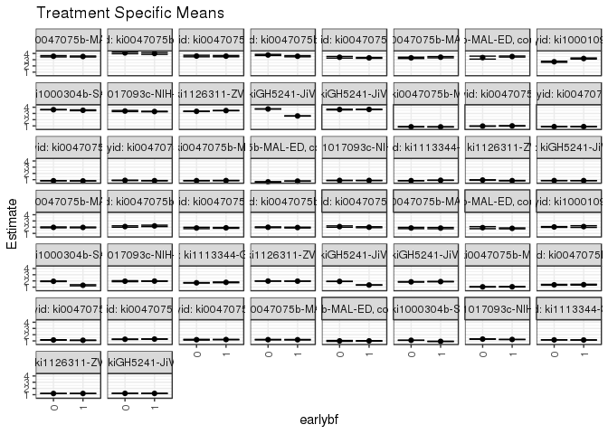

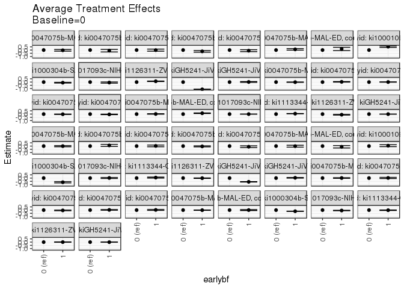

## Results Table

### Parameter: TSM

| agecat | studyid | country | intervention_level | baseline_level | estimate | ci_lower | ci_upper |
| --- | --- | --- | --- | --- | --- | --- | --- |
| 0-3 months | ki0047075b-MAL-ED | BANGLADESH | 0 | NA | 3.5535976 | 3.4472439 | 3.6599512 |
| 0-3 months | ki0047075b-MAL-ED | BANGLADESH | 1 | NA | 3.5136998 | 3.4391551 | 3.5882445 |
| 0-3 months | ki0047075b-MAL-ED | BRAZIL | 0 | NA | 4.0930244 | 3.9548379 | 4.2312109 |
| 0-3 months | ki0047075b-MAL-ED | BRAZIL | 1 | NA | 3.9960126 | 3.8519694 | 4.1400559 |
| 0-3 months | ki0047075b-MAL-ED | INDIA | 0 | NA | 3.5851627 | 3.4607693 | 3.7095561 |
| 0-3 months | ki0047075b-MAL-ED | INDIA | 1 | NA | 3.5705126 | 3.4694889 | 3.6715363 |
| 0-3 months | ki0047075b-MAL-ED | NEPAL | 0 | NA | 3.7567775 | 3.6661318 | 3.8474232 |
| 0-3 months | ki0047075b-MAL-ED | NEPAL | 1 | NA | 3.5556255 | 3.4600235 | 3.6512274 |
| 0-3 months | ki0047075b-MAL-ED | PERU | 0 | NA | 3.3906621 | 3.2603018 | 3.5210225 |
| 0-3 months | ki0047075b-MAL-ED | PERU | 1 | NA | 3.2907963 | 3.2189668 | 3.3626258 |
| 0-3 months | ki0047075b-MAL-ED | SOUTH AFRICA | 0 | NA | 3.2950847 | 3.1891913 | 3.4009781 |
| 0-3 months | ki0047075b-MAL-ED | SOUTH AFRICA | 1 | NA | 3.4009453 | 3.2996375 | 3.5022532 |
| 0-3 months | ki0047075b-MAL-ED | TANZANIA, UNITED REPUBLIC OF | 0 | NA | 3.3325440 | 3.0960290 | 3.5690590 |
| 0-3 months | ki0047075b-MAL-ED | TANZANIA, UNITED REPUBLIC OF | 1 | NA | 3.5059172 | 3.4253286 | 3.5865058 |
| 0-3 months | ki1000109-EE | PAKISTAN | 0 | NA | 2.6670082 | 2.5750961 | 2.7589204 |
| 0-3 months | ki1000109-EE | PAKISTAN | 1 | NA | 3.1902411 | 3.1063574 | 3.2741248 |
| 0-3 months | ki1000304b-SAS-CompFeed | INDIA | 0 | NA | 3.6031693 | 3.5746782 | 3.6316604 |
| 0-3 months | ki1000304b-SAS-CompFeed | INDIA | 1 | NA | 3.5076098 | 3.4438493 | 3.5713703 |
| 0-3 months | ki1017093c-NIH-Crypto | BANGLADESH | 0 | NA | 3.3870142 | 3.2973143 | 3.4767142 |
| 0-3 months | ki1017093c-NIH-Crypto | BANGLADESH | 1 | NA | 3.3079080 | 3.2675783 | 3.3482377 |
| 0-3 months | ki1126311-ZVITAMBO | ZIMBABWE | 0 | NA | 3.3395705 | 3.3094252 | 3.3697159 |
| 0-3 months | ki1126311-ZVITAMBO | ZIMBABWE | 1 | NA | 3.4611027 | 3.4330356 | 3.4891698 |
| 0-3 months | kiGH5241-JiVitA-3 | BANGLADESH | 0 | NA | 3.7197234 | 3.7093616 | 3.7300852 |
| 0-3 months | kiGH5241-JiVitA-3 | BANGLADESH | 1 | NA | 2.5939426 | 2.5707393 | 2.6171459 |
| 0-3 months | kiGH5241-JiVitA-4 | BANGLADESH | 0 | NA | 3.6276422 | 3.5725237 | 3.6827607 |
| 0-3 months | kiGH5241-JiVitA-4 | BANGLADESH | 1 | NA | 3.6422548 | 3.6048247 | 3.6796848 |
| 3-6 months | ki0047075b-MAL-ED | BANGLADESH | 0 | NA | 1.9689681 | 1.8999083 | 2.0380278 |
| 3-6 months | ki0047075b-MAL-ED | BANGLADESH | 1 | NA | 1.9605851 | 1.8959455 | 2.0252247 |
| 3-6 months | ki0047075b-MAL-ED | BRAZIL | 0 | NA | 2.1011152 | 1.9924372 | 2.2097932 |
| 3-6 months | ki0047075b-MAL-ED | BRAZIL | 1 | NA | 2.2033645 | 2.0888522 | 2.3178768 |

[output cut: 70 more lines]

### Parameter: E(Y)

| agecat | studyid | country | intervention_level | baseline_level | estimate | ci_lower | ci_upper |
| --- | --- | --- | --- | --- | --- | --- | --- |
| 0-3 months | ki0047075b-MAL-ED | BANGLADESH | NA | NA | 3.5631693 | 3.5001026 | 3.6262360 |
| 0-3 months | ki0047075b-MAL-ED | BRAZIL | NA | NA | 4.0509714 | 3.9492443 | 4.1526985 |
| 0-3 months | ki0047075b-MAL-ED | INDIA | NA | NA | 3.5764512 | 3.4977133 | 3.6551891 |
| 0-3 months | ki0047075b-MAL-ED | NEPAL | NA | NA | 3.8204935 | 3.7444190 | 3.8965681 |
| 0-3 months | ki0047075b-MAL-ED | PERU | NA | NA | 3.3158605 | 3.2526447 | 3.3790763 |
| 0-3 months | ki0047075b-MAL-ED | SOUTH AFRICA | NA | NA | 3.4465475 | 3.3566656 | 3.5364293 |
| 0-3 months | ki0047075b-MAL-ED | TANZANIA, UNITED REPUBLIC OF | NA | NA | 3.4816904 | 3.4044928 | 3.5588880 |
| 0-3 months | ki1000109-EE | PAKISTAN | NA | NA | 2.6575645 | 2.5739973 | 2.7411317 |
| 0-3 months | ki1000304b-SAS-CompFeed | INDIA | NA | NA | 3.6019890 | 3.5739652 | 3.6300127 |
| 0-3 months | ki1017093c-NIH-Crypto | BANGLADESH | NA | NA | 3.3028656 | 3.2646714 | 3.3410598 |
| 0-3 months | ki1126311-ZVITAMBO | ZIMBABWE | NA | NA | 3.3690914 | 3.3467990 | 3.3913838 |
| 0-3 months | kiGH5241-JiVitA-3 | BANGLADESH | NA | NA | 3.7184443 | 3.7081005 | 3.7287881 |
| 0-3 months | kiGH5241-JiVitA-4 | BANGLADESH | NA | NA | 3.6381167 | 3.6070177 | 3.6692156 |
| 3-6 months | ki0047075b-MAL-ED | BANGLADESH | NA | NA | 1.9292289 | 1.8797750 | 1.9786828 |
| 3-6 months | ki0047075b-MAL-ED | BRAZIL | NA | NA | 2.1478156 | 2.0686357 | 2.2269955 |
| 3-6 months | ki0047075b-MAL-ED | INDIA | NA | NA | 1.8837264 | 1.8224393 | 1.9450135 |
| 3-6 months | ki0047075b-MAL-ED | NEPAL | NA | NA | 1.9680995 | 1.9120346 | 2.0241643 |
| 3-6 months | ki0047075b-MAL-ED | PERU | NA | NA | 2.0183213 | 1.9525900 | 2.0840526 |
| 3-6 months | ki0047075b-MAL-ED | SOUTH AFRICA | NA | NA | 1.9784427 | 1.8974503 | 2.0594352 |
| 3-6 months | ki0047075b-MAL-ED | TANZANIA, UNITED REPUBLIC OF | NA | NA | 1.8300902 | 1.7622436 | 1.8979368 |
| 3-6 months | ki1000109-EE | PAKISTAN | NA | NA | 2.0241201 | 1.9636505 | 2.0845898 |
| 3-6 months | ki1000304b-SAS-CompFeed | INDIA | NA | NA | 1.9406419 | 1.8967379 | 1.9845458 |
| 3-6 months | ki1017093c-NIH-Crypto | BANGLADESH | NA | NA | 2.0057973 | 1.9693775 | 2.0422170 |
| 3-6 months | ki1113344-GMS-Nepal | NEPAL | NA | NA | 1.7109584 | 1.6711424 | 1.7507745 |
| 3-6 months | ki1126311-ZVITAMBO | ZIMBABWE | NA | NA | 1.9802288 | 1.9591364 | 2.0013212 |
| 3-6 months | kiGH5241-JiVitA-3 | BANGLADESH | NA | NA | 1.9201861 | 1.9097195 | 1.9306528 |
| 3-6 months | kiGH5241-JiVitA-4 | BANGLADESH | NA | NA | 1.8983676 | 1.8684335 | 1.9283018 |
| 6-12 months | ki0047075b-MAL-ED | BANGLADESH | NA | NA | 1.1152078 | 1.0903637 | 1.1400520 |
| 6-12 months | ki0047075b-MAL-ED | BRAZIL | NA | NA | 1.3863464 | 1.3400121 | 1.4326807 |
| 6-12 months | ki0047075b-MAL-ED | INDIA | NA | NA | 1.1210558 | 1.0926349 | 1.1494766 |
| 6-12 months | ki0047075b-MAL-ED | NEPAL | NA | NA | 1.2224454 | 1.1966480 | 1.2482429 |
| 6-12 months | ki0047075b-MAL-ED | PERU | NA | NA | 1.2102315 | 1.1775158 | 1.2429472 |
| 6-12 months | ki0047075b-MAL-ED | SOUTH AFRICA | NA | NA | 1.1877172 | 1.1461593 | 1.2292750 |
| 6-12 months | ki0047075b-MAL-ED | TANZANIA, UNITED REPUBLIC OF | NA | NA | 1.0019524 | 0.9648566 | 1.0390481 |
| 6-12 months | ki1000304b-SAS-CompFeed | INDIA | NA | NA | 1.0983052 | 1.0864567 | 1.1101538 |
| 6-12 months | ki1017093c-NIH-Crypto | BANGLADESH | NA | NA | 1.2281313 | 1.2106849 | 1.2455776 |
| 6-12 months | ki1113344-GMS-Nepal | NEPAL | NA | NA | 1.1658247 | 1.1454282 | 1.1862212 |
| 6-12 months | ki1126311-ZVITAMBO | ZIMBABWE | NA | NA | 1.1959631 | 1.1843049 | 1.2076212 |
| 6-12 months | kiGH5241-JiVitA-4 | BANGLADESH | NA | NA | 1.2032186 | 1.1928228 | 1.2136143 |
| 12-24 months | ki0047075b-MAL-ED | BANGLADESH | NA | NA | 0.8470460 | 0.8311013 | 0.8629906 |
| 12-24 months | ki0047075b-MAL-ED | BRAZIL | NA | NA | 0.9816245 | 0.9508764 | 1.0123725 |
| 12-24 months | ki0047075b-MAL-ED | INDIA | NA | NA | 0.8803730 | 0.8630530 | 0.8976931 |
| 12-24 months | ki0047075b-MAL-ED | NEPAL | NA | NA | 0.8617083 | 0.8463512 | 0.8770654 |
| 12-24 months | ki0047075b-MAL-ED | PERU | NA | NA | 0.8463453 | 0.8256453 | 0.8670453 |
| 12-24 months | ki0047075b-MAL-ED | SOUTH AFRICA | NA | NA | 0.8712442 | 0.8486351 | 0.8938532 |
| 12-24 months | ki0047075b-MAL-ED | TANZANIA, UNITED REPUBLIC OF | NA | NA | 0.7663111 | 0.7428636 | 0.7897586 |
| 12-24 months | ki1017093c-NIH-Crypto | BANGLADESH | NA | NA | 0.8755729 | 0.8637860 | 0.8873598 |
| 12-24 months | ki1113344-GMS-Nepal | NEPAL | NA | NA | 0.8399115 | 0.8236717 | 0.8561513 |
| 12-24 months | ki1126311-ZVITAMBO | ZIMBABWE | NA | NA | 0.7070642 | 0.6793316 | 0.7347968 |
| 12-24 months | kiGH5241-JiVitA-4 | BANGLADESH | NA | NA | 0.8491886 | 0.8437514 | 0.8546258 |

### Parameter: ATE

| agecat | studyid | country | intervention_level | baseline_level | estimate | ci_lower | ci_upper |
| --- | --- | --- | --- | --- | --- | --- | --- |
| 0-3 months | ki0047075b-MAL-ED | BANGLADESH | 0 | 0 | 0.0000000 | 0.0000000 | 0.0000000 |
| 0-3 months | ki0047075b-MAL-ED | BANGLADESH | 1 | 0 | -0.0398978 | -0.1687124 | 0.0889168 |
| 0-3 months | ki0047075b-MAL-ED | BRAZIL | 0 | 0 | 0.0000000 | 0.0000000 | 0.0000000 |
| 0-3 months | ki0047075b-MAL-ED | BRAZIL | 1 | 0 | -0.0970117 | -0.2937616 | 0.0997381 |
| 0-3 months | ki0047075b-MAL-ED | INDIA | 0 | 0 | 0.0000000 | 0.0000000 | 0.0000000 |
| 0-3 months | ki0047075b-MAL-ED | INDIA | 1 | 0 | -0.0146501 | -0.1742544 | 0.1449542 |
| 0-3 months | ki0047075b-MAL-ED | NEPAL | 0 | 0 | 0.0000000 | 0.0000000 | 0.0000000 |
| 0-3 months | ki0047075b-MAL-ED | NEPAL | 1 | 0 | -0.2011520 | -0.3259205 | -0.0763836 |
| 0-3 months | ki0047075b-MAL-ED | PERU | 0 | 0 | 0.0000000 | 0.0000000 | 0.0000000 |
| 0-3 months | ki0047075b-MAL-ED | PERU | 1 | 0 | -0.0998658 | -0.2486390 | 0.0489074 |
| 0-3 months | ki0047075b-MAL-ED | SOUTH AFRICA | 0 | 0 | 0.0000000 | 0.0000000 | 0.0000000 |
| 0-3 months | ki0047075b-MAL-ED | SOUTH AFRICA | 1 | 0 | 0.1058606 | -0.0180413 | 0.2297625 |
| 0-3 months | ki0047075b-MAL-ED | TANZANIA, UNITED REPUBLIC OF | 0 | 0 | 0.0000000 | 0.0000000 | 0.0000000 |
| 0-3 months | ki0047075b-MAL-ED | TANZANIA, UNITED REPUBLIC OF | 1 | 0 | 0.1733732 | -0.0764945 | 0.4232409 |
| 0-3 months | ki1000109-EE | PAKISTAN | 0 | 0 | 0.0000000 | 0.0000000 | 0.0000000 |
| 0-3 months | ki1000109-EE | PAKISTAN | 1 | 0 | 0.5232329 | 0.4096464 | 0.6368194 |
| 0-3 months | ki1000304b-SAS-CompFeed | INDIA | 0 | 0 | 0.0000000 | 0.0000000 | 0.0000000 |
| 0-3 months | ki1000304b-SAS-CompFeed | INDIA | 1 | 0 | -0.0955595 | -0.1573182 | -0.0338007 |
| 0-3 months | ki1017093c-NIH-Crypto | BANGLADESH | 0 | 0 | 0.0000000 | 0.0000000 | 0.0000000 |
| 0-3 months | ki1017093c-NIH-Crypto | BANGLADESH | 1 | 0 | -0.0791062 | -0.1763756 | 0.0181631 |
| 0-3 months | ki1126311-ZVITAMBO | ZIMBABWE | 0 | 0 | 0.0000000 | 0.0000000 | 0.0000000 |
| 0-3 months | ki1126311-ZVITAMBO | ZIMBABWE | 1 | 0 | 0.1215322 | 0.0811107 | 0.1619537 |
| 0-3 months | kiGH5241-JiVitA-3 | BANGLADESH | 0 | 0 | 0.0000000 | 0.0000000 | 0.0000000 |
| 0-3 months | kiGH5241-JiVitA-3 | BANGLADESH | 1 | 0 | -1.1257808 | -1.1511157 | -1.1004459 |
| 0-3 months | kiGH5241-JiVitA-4 | BANGLADESH | 0 | 0 | 0.0000000 | 0.0000000 | 0.0000000 |
| 0-3 months | kiGH5241-JiVitA-4 | BANGLADESH | 1 | 0 | 0.0146126 | -0.0519804 | 0.0812056 |
| 3-6 months | ki0047075b-MAL-ED | BANGLADESH | 0 | 0 | 0.0000000 | 0.0000000 | 0.0000000 |
| 3-6 months | ki0047075b-MAL-ED | BANGLADESH | 1 | 0 | -0.0083829 | -0.1023596 | 0.0855937 |
| 3-6 months | ki0047075b-MAL-ED | BRAZIL | 0 | 0 | 0.0000000 | 0.0000000 | 0.0000000 |
| 3-6 months | ki0047075b-MAL-ED | BRAZIL | 1 | 0 | 0.1022493 | -0.0556240 | 0.2601226 |

[output cut: 70 more lines]